# Week 4, clustering and classification

## Exercise 4

In this exercise we use a data set called “Boston”, which contains data gathered from the city of Boston. The data set for example contains information about housing such as value of houses, property tax, and number of rooms in a house. Other data include for example crime rates, pollution rates, zoning, and accessibility to highways.

```r
library(MASS)

data("Boston")

dim(Boston)
```

```
## [1] 506  14
```

```r
str(Boston)
```

```
## 'data.frame':    506 obs. of  14 variables:
##  $ crim   : num  0.00632 0.02731 0.02729 0.03237 0.06905 ...
##  $ zn     : num  18 0 0 0 0 0 12.5 12.5 12.5 12.5 ...
##  $ indus  : num  2.31 7.07 7.07 2.18 2.18 2.18 7.87 7.87 7.87 7.87 ...
##  $ chas   : int  0 0 0 0 0 0 0 0 0 0 ...
##  $ nox    : num  0.538 0.469 0.469 0.458 0.458 0.458 0.524 0.524 0.524 0.524 ...
##  $ rm     : num  6.58 6.42 7.18 7 7.15 ...
##  $ age    : num  65.2 78.9 61.1 45.8 54.2 58.7 66.6 96.1 100 85.9 ...
##  $ dis    : num  4.09 4.97 4.97 6.06 6.06 ...
##  $ rad    : int  1 2 2 3 3 3 5 5 5 5 ...
##  $ tax    : num  296 242 242 222 222 222 311 311 311 311 ...
##  $ ptratio: num  15.3 17.8 17.8 18.7 18.7 18.7 15.2 15.2 15.2 15.2 ...
##  $ black  : num  397 397 393 395 397 ...
##  $ lstat  : num  4.98 9.14 4.03 2.94 5.33 ...
##  $ medv   : num  24 21.6 34.7 33.4 36.2 28.7 22.9 27.1 16.5 18.9 ...
```

The Boston data set has 14 columns and 506 rows and all of the data is numeric.

```r
library(ggplot2)
library(GGally)
library(corrplot)
summary(Boston)
```

```
##       crim                zn             indus            chas
##  Min.   : 0.00632   Min.   :  0.00   Min.   : 0.46   Min.   :0.00000
##  1st Qu.: 0.08205   1st Qu.:  0.00   1st Qu.: 5.19   1st Qu.:0.00000
##  Median : 0.25651   Median :  0.00   Median : 9.69   Median :0.00000
##  Mean   : 3.61352   Mean   : 11.36   Mean   :11.14   Mean   :0.06917
##  3rd Qu.: 3.67708   3rd Qu.: 12.50   3rd Qu.:18.10   3rd Qu.:0.00000
##  Max.   :88.97620   Max.   :100.00   Max.   :27.74   Max.   :1.00000
##       nox               rm             age              dis
##  Min.   :0.3850   Min.   :3.561   Min.   :  2.90   Min.   : 1.130
##  1st Qu.:0.4490   1st Qu.:5.886   1st Qu.: 45.02   1st Qu.: 2.100
##  Median :0.5380   Median :6.208   Median : 77.50   Median : 3.207
##  Mean   :0.5547   Mean   :6.285   Mean   : 68.57   Mean   : 3.795
##  3rd Qu.:0.6240   3rd Qu.:6.623   3rd Qu.: 94.08   3rd Qu.: 5.188
##  Max.   :0.8710   Max.   :8.780   Max.   :100.00   Max.   :12.127
##       rad              tax           ptratio          black
##  Min.   : 1.000   Min.   :187.0   Min.   :12.60   Min.   :  0.32
##  1st Qu.: 4.000   1st Qu.:279.0   1st Qu.:17.40   1st Qu.:375.38
##  Median : 5.000   Median :330.0   Median :19.05   Median :391.44
##  Mean   : 9.549   Mean   :408.2   Mean   :18.46   Mean   :356.67
##  3rd Qu.:24.000   3rd Qu.:666.0   3rd Qu.:20.20   3rd Qu.:396.23
##  Max.   :24.000   Max.   :711.0   Max.   :22.00   Max.   :396.90
##      lstat            medv
##  Min.   : 1.73   Min.   : 5.00
##  1st Qu.: 6.95   1st Qu.:17.02
##  Median :11.36   Median :21.20
##  Mean   :12.65   Mean   :22.53
##  3rd Qu.:16.95   3rd Qu.:25.00
##  Max.   :37.97   Max.   :50.00
```

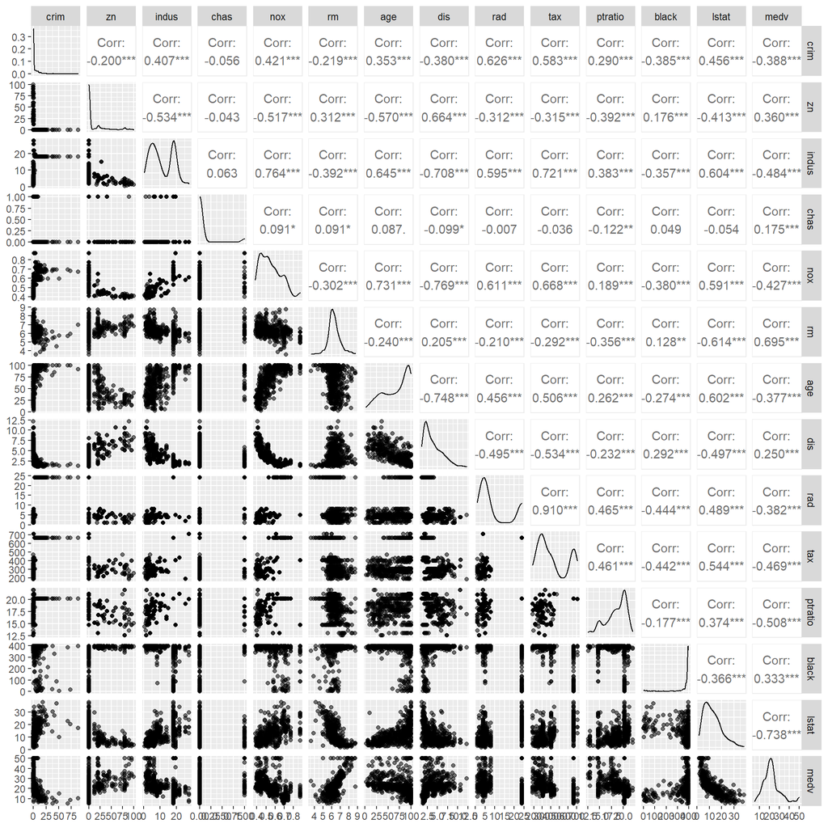

```r
p <- ggpairs(Boston, mapping = aes(alpha = 0.3), lower = list(combo = wrap("facethist", bins = 20)))
p
```

```r
cor_matrix<-cor(Boston)
cor_matrix %>% round(2)
```

```
##          crim    zn indus  chas   nox    rm   age   dis   rad   tax ptratio
## crim     1.00 -0.20  0.41 -0.06  0.42 -0.22  0.35 -0.38  0.63  0.58    0.29
## zn      -0.20  1.00 -0.53 -0.04 -0.52  0.31 -0.57  0.66 -0.31 -0.31   -0.39
## indus    0.41 -0.53  1.00  0.06  0.76 -0.39  0.64 -0.71  0.60  0.72    0.38
## chas    -0.06 -0.04  0.06  1.00  0.09  0.09  0.09 -0.10 -0.01 -0.04   -0.12
## nox      0.42 -0.52  0.76  0.09  1.00 -0.30  0.73 -0.77  0.61  0.67    0.19
## rm      -0.22  0.31 -0.39  0.09 -0.30  1.00 -0.24  0.21 -0.21 -0.29   -0.36
## age      0.35 -0.57  0.64  0.09  0.73 -0.24  1.00 -0.75  0.46  0.51    0.26
## dis     -0.38  0.66 -0.71 -0.10 -0.77  0.21 -0.75  1.00 -0.49 -0.53   -0.23
## rad      0.63 -0.31  0.60 -0.01  0.61 -0.21  0.46 -0.49  1.00  0.91    0.46
## tax      0.58 -0.31  0.72 -0.04  0.67 -0.29  0.51 -0.53  0.91  1.00    0.46
## ptratio  0.29 -0.39  0.38 -0.12  0.19 -0.36  0.26 -0.23  0.46  0.46    1.00
## black   -0.39  0.18 -0.36  0.05 -0.38  0.13 -0.27  0.29 -0.44 -0.44   -0.18
## lstat    0.46 -0.41  0.60 -0.05  0.59 -0.61  0.60 -0.50  0.49  0.54    0.37
## medv    -0.39  0.36 -0.48  0.18 -0.43  0.70 -0.38  0.25 -0.38 -0.47   -0.51
##         black lstat  medv
## crim    -0.39  0.46 -0.39
## zn       0.18 -0.41  0.36
## indus   -0.36  0.60 -0.48
## chas     0.05 -0.05  0.18
## nox     -0.38  0.59 -0.43
## rm       0.13 -0.61  0.70
## age     -0.27  0.60 -0.38
## dis      0.29 -0.50  0.25
## rad     -0.44  0.49 -0.38
## tax     -0.44  0.54 -0.47
## ptratio -0.18  0.37 -0.51
## black    1.00 -0.37  0.33
## lstat   -0.37  1.00 -0.74
## medv     0.33 -0.74  1.00
```

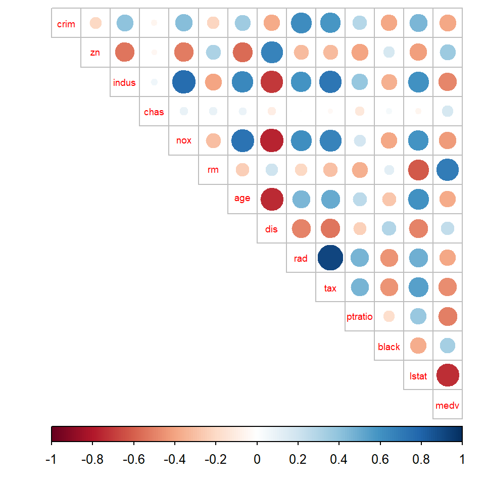

```r
corrplot(cor_matrix, method="circle", type = "upper", cl.pos = "b", tl.pos = "d", tl.cex = 0.6)
```

Based on the plots most of the columns do not seem to follow the normal distribution and instead we can see multiple peaks in the data. There seems to be strong negative correlations between ‘dis’ and ‘indus’ (non-retail business) , ‘nox’ (nitrogen oxides) , and ‘age’ (built prior to 1940). A very strong correlation can also be seen between ‘lstat’ (lower status population) and ‘medv’ (median value of homes). It is not particularly surprising that lower status population could afford only cheaper homes.

A strong positive correlation seems to exits between ‘rad’ (access to radial highways) and ‘tax’ (property tax) as well as ‘indus’ and ‘nox’ and between ‘nox’ and ‘age’. It is again not that surprising that areas with more industry would have higher nitrogen oxide levels.

In the summary we can see that crime rates vary from very low with a minimum of 0.006 to very high with a crime rate of 88.98. The median is closer to the low rate so this very high rate is clearly some kind of anomaly within Boston and not reflective of the entire city.

The age variable indicates that there are areas in Boston where almost no houses are old and then there are areas where are houses are old. But old houses seem to be common overall as the first quantile is at 45%.

Standardizing data:

```r
boston_stand <- as.data.frame(scale(Boston))
summary(boston_stand)
```

```
##       crim                 zn               indus              chas
##  Min.   :-0.419367   Min.   :-0.48724   Min.   :-1.5563   Min.   :-0.2723
##  1st Qu.:-0.410563   1st Qu.:-0.48724   1st Qu.:-0.8668   1st Qu.:-0.2723
##  Median :-0.390280   Median :-0.48724   Median :-0.2109   Median :-0.2723
##  Mean   : 0.000000   Mean   : 0.00000   Mean   : 0.0000   Mean   : 0.0000
##  3rd Qu.: 0.007389   3rd Qu.: 0.04872   3rd Qu.: 1.0150   3rd Qu.:-0.2723
##  Max.   : 9.924110   Max.   : 3.80047   Max.   : 2.4202   Max.   : 3.6648
##       nox                rm               age               dis
##  Min.   :-1.4644   Min.   :-3.8764   Min.   :-2.3331   Min.   :-1.2658
##  1st Qu.:-0.9121   1st Qu.:-0.5681   1st Qu.:-0.8366   1st Qu.:-0.8049
##  Median :-0.1441   Median :-0.1084   Median : 0.3171   Median :-0.2790
##  Mean   : 0.0000   Mean   : 0.0000   Mean   : 0.0000   Mean   : 0.0000
##  3rd Qu.: 0.5981   3rd Qu.: 0.4823   3rd Qu.: 0.9059   3rd Qu.: 0.6617
##  Max.   : 2.7296   Max.   : 3.5515   Max.   : 1.1164   Max.   : 3.9566
##       rad               tax             ptratio            black
##  Min.   :-0.9819   Min.   :-1.3127   Min.   :-2.7047   Min.   :-3.9033
##  1st Qu.:-0.6373   1st Qu.:-0.7668   1st Qu.:-0.4876   1st Qu.: 0.2049
##  Median :-0.5225   Median :-0.4642   Median : 0.2746   Median : 0.3808
##  Mean   : 0.0000   Mean   : 0.0000   Mean   : 0.0000   Mean   : 0.0000
##  3rd Qu.: 1.6596   3rd Qu.: 1.5294   3rd Qu.: 0.8058   3rd Qu.: 0.4332
##  Max.   : 1.6596   Max.   : 1.7964   Max.   : 1.6372   Max.   : 0.4406
##      lstat              medv
##  Min.   :-1.5296   Min.   :-1.9063
##  1st Qu.:-0.7986   1st Qu.:-0.5989
##  Median :-0.1811   Median :-0.1449
##  Mean   : 0.0000   Mean   : 0.0000
##  3rd Qu.: 0.6024   3rd Qu.: 0.2683
##  Max.   : 3.5453   Max.   : 2.9865
```

```r
bins <- quantile(boston_stand$crim)
bins
```

```
##           0%          25%          50%          75%         100%
## -0.419366929 -0.410563278 -0.390280295  0.007389247  9.924109610
```

```r
crime <- cut(boston_stand$crim, breaks = bins, include.lowest = TRUE, label = c("low", "med_low", "med_high", "high"))

boston_stand$crim <- crime #no need to remove the crime column when it can be just replaced

table(crime)
```

```
## crime
##      low  med_low med_high     high
##      127      126      126      127
```

Since the data has bee scaled it now is distributed around a 0 mean so all variables have a 0 mean in the summary.

The distribution of crime rates seem to be approximately equally distributed between the four crime levels.

Fitting a LDA model and drawing a plot:

```r
n <- nrow(boston_stand)
ind <- sample(n, size = n*0.8) #splitting data into train and test sets
train <- boston_stand[ind,]
test <- boston_stand[-ind,]
```

```r
lda.fit <- lda(crim ~ ., data = train)
lda.fit
```

```
## Call:
## lda(crim ~ ., data = train)
##
## Prior probabilities of groups:
##       low   med_low  med_high      high
## 0.2698020 0.2549505 0.2301980 0.2450495
##
## Group means:
##                   zn      indus        chas        nox           rm        age
## low       0.91610095 -0.9093988 -0.12784833 -0.8732525  0.442472193 -0.8627997
## med_low  -0.07824226 -0.2986885 -0.04298342 -0.5529510 -0.088950954 -0.3043165
## med_high -0.37474533  0.2259666  0.10868063  0.3871676  0.003933098  0.3962933
## high     -0.48724019  1.0171737 -0.03371693  1.0701104 -0.494856974  0.7916372
##                 dis        rad        tax     ptratio      black        lstat
## low       0.8992606 -0.6794767 -0.7431380 -0.46763963  0.3740858 -0.755462805
## med_low   0.3299434 -0.5436697 -0.4331060 -0.08529536  0.3126448 -0.146215125
## med_high -0.3561395 -0.4150472 -0.2945049 -0.22630694  0.1134237  0.006181302
## high     -0.8622865  1.6375616  1.5136504  0.78011702 -0.8565363  0.887295212
##                medv
## low       0.5337980
## med_low   0.0368636
## med_high  0.1183741
## high     -0.6730795
##
## Coefficients of linear discriminants:
##                  LD1          LD2         LD3
## zn       0.120240383  0.606080310 -0.90213782
## indus   -0.004227216 -0.365203102  0.04027767
## chas    -0.003939538 -0.022417375  0.13423306
## nox      0.480869599 -0.738600546 -1.46746384
## rm       0.026719863 -0.015374042 -0.08423182
## age      0.225012816 -0.324235567 -0.04358625
## dis     -0.069557109 -0.247023211  0.01098593
## rad      3.089499778  0.957422597 -0.36967720
## tax      0.023241954  0.040614070  1.01445834
## ptratio  0.157855797 -0.000716169 -0.27156671
## black   -0.125315291  0.001804152  0.10872086
## lstat    0.204469077 -0.143768122  0.41430182
## medv     0.124353396 -0.341899782 -0.17039908
##
## Proportion of trace:
##    LD1    LD2    LD3
## 0.9530 0.0354 0.0117
```

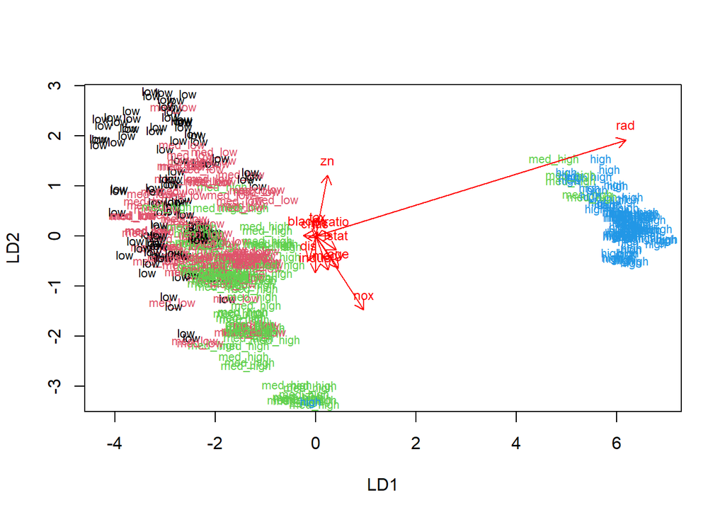

```r
#copied from the datacamp exercise

lda.arrows <- function(x, myscale = 1, arrow_heads = 0.1, color = "red", tex = 0.75, choices = c(1,2)){
  heads <- coef(x)
  arrows(x0 = 0, y0 = 0,
         x1 = myscale * heads[,choices[1]],
         y1 = myscale * heads[,choices[2]], col=color, length = arrow_heads)
  text(myscale * heads[,choices], labels = row.names(heads),
       cex = tex, col=color, pos=3)
}

classes <- as.numeric(train$crim)

plot(lda.fit, dimen = 2, col = classes, pch = classes)
lda.arrows(lda.fit, myscale = 2)
```

The high crime rate and some medium high crime rate datapoints seem to form their own cluster. ‘rad’ (accessibility to radial highways) seems to be the feature that separates this cluster from the others. In the previous correlation plots we can see that there is indeed a positive correaltion between crime rate and ‘rad’.

‘zn’ and ‘nox’ seem to separate the other axis. In this case it separates out the lower crime areas from the medium high ones. The ‘zn’ (residential lots) and ‘nox’ (nitrogen oxide levels) probably correlate between more quiet residential areas and industrial areas or areas near them.

Predicting:

```r
correct <- test$crim
test <- dplyr::select(test, -crim)

lda.pred <- predict(lda.fit, newdata = test)
table(correct = correct, predicted = lda.pred$class)
```

```
##           predicted
## correct    low med_low med_high high
##   low       14       4        0    0
##   med_low    5      15        3    0
##   med_high   0       9       23    1
##   high       0       0        0   28
```

The model seems to predict well the high crime rates, but has trouble separating the medium crime levels. Predicting low crime rates works quite well, but the model has trouble separating the low and medium low rates from each other. Similarly the model has problems separating medium low and medium high rates from each other.

Clustering with k-means:

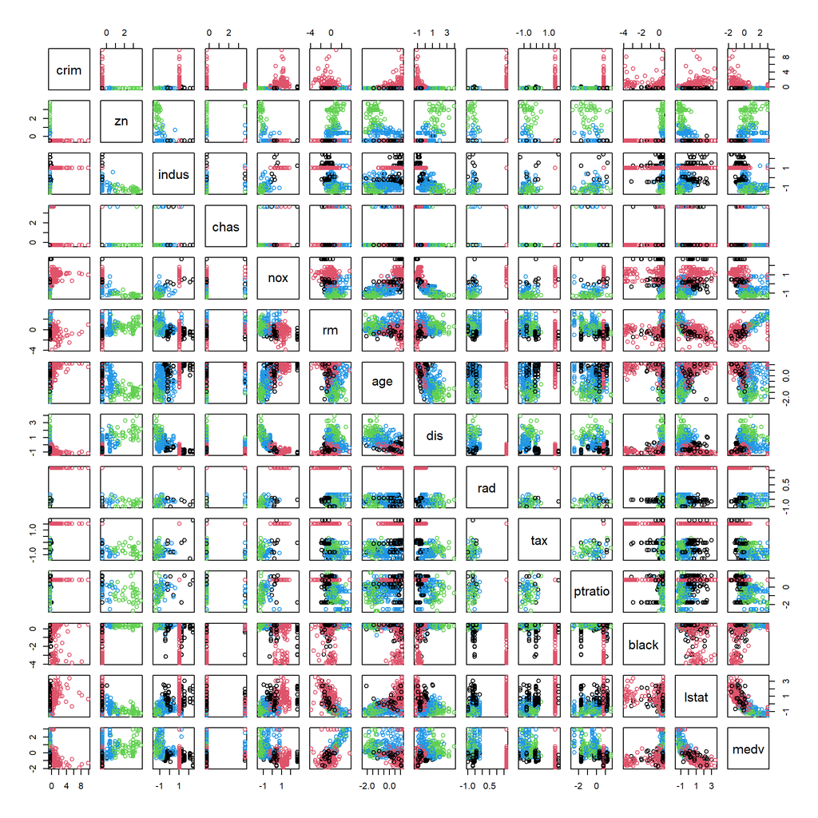

```r
data("Boston")
scaled_boston <- scale(Boston)

dist_eu <- dist(scaled_boston)

km <-kmeans(scaled_boston, centers = 4)

pairs(scaled_boston, col = km$cluster)
```

4 clusters does not seem to be all that great as there is still overlap between the different clusters and as the LDA prediction indicated a lower number of clusters is probably better since there is confusion between the classes.

Investigating how many clusters would be good:

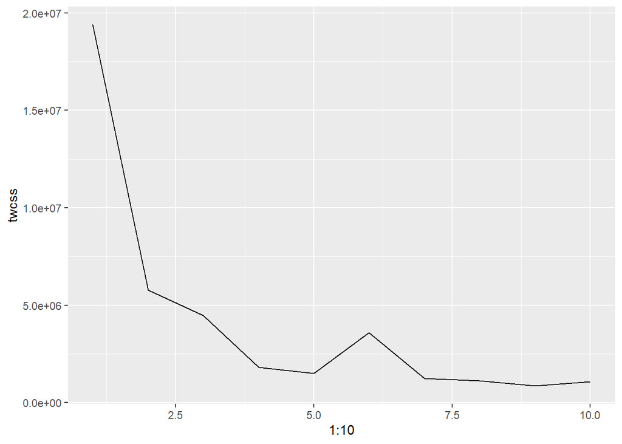

```r
twcss <- sapply(1:10, function(k){kmeans(Boston, k)$tot.withinss})
qplot(x = 1:10, y = twcss, geom = 'line')
```

According to the plot 2 clusters seems to be a good number to try.

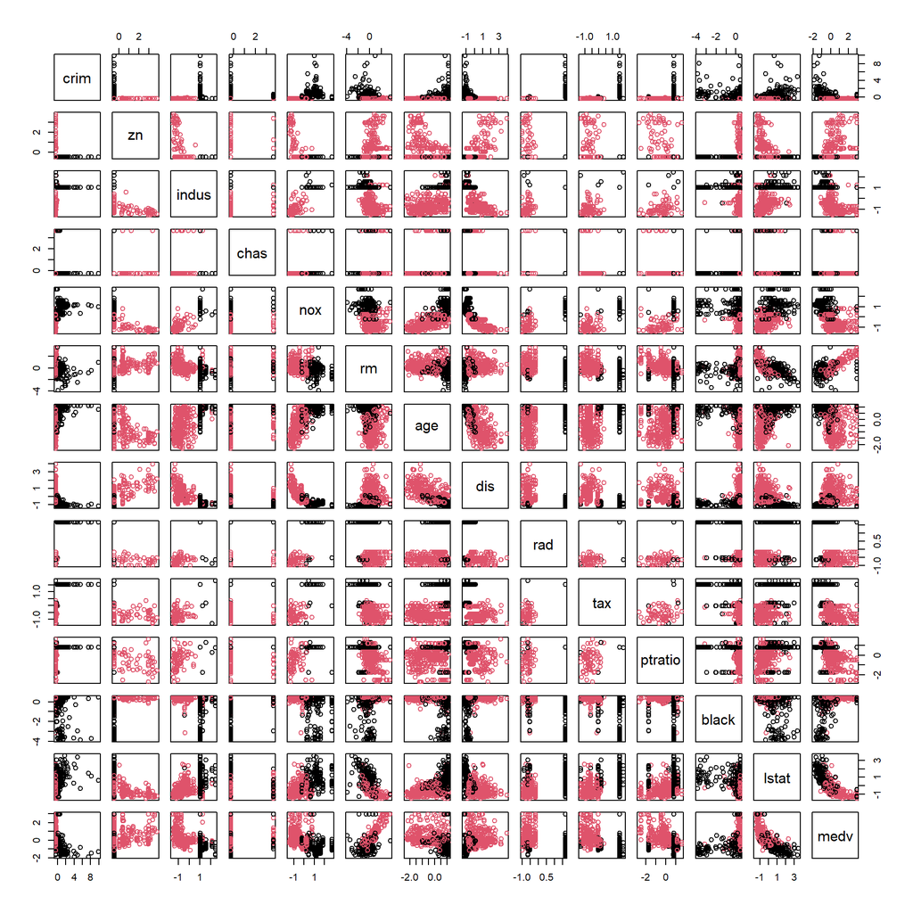

```r
km <-kmeans(scaled_boston, centers = 2)
pairs(scaled_boston, col = km$cluster)
```

Now we can see the clusters much easily. It is probably better in the model to separate the crime rate into a high one and low to medium levels.

In the plots we can see for example in the ‘lstat’ and ‘medv’ a clear separation between the two clusters and it would be easy to draw a straight line between them to separate the to clusters. There are also plots where the two clusters are completely separate from each other.